# Projeto 1

Lorenna Diniz Dantas

2023-06-07

# Objetivo Geral

Analisar quais são os fatores que determinam o desempenho em matemática nos diferentes distritos do estado da Califórnia, e ajudar na tomada de decisões para o uso adequado dos recursos.

# Estudo de dados

1. Carregando os pacotes que serão utilizados:

```r
library("readxl")
library("dplyr")
library("pastecs")
library("ggpubr")
library("corrplot")
library("tidyverse")
library("tidylog")
library("nycflights13")
library("ggplot2")
library("plotrix")
```

2. Importando dados do Excel:

```r
CASchools <- read_excel("C:/Users/User/Documents/Estudando/CASchools.xlsx")
View(CASchools)
```

3. Verificando o número, nome, e classe das variáveis. Em seguida, o sumário dos dados:

```r
dim(CASchools)
```

```
## [1] 420  15
```

```r
names(CASchools)
```

```
##  [1] "...1"        "district"    "school"      "county"      "grades"
##  [6] "students"    "teachers"    "calworks"    "lunch"       "computer"
## [11] "expenditure" "income"      "english"     "read"        "math"
```

```r
str(CASchools)
```

```
## tibble [420 × 15] (S3: tbl_df/tbl/data.frame)
##  $ ...1       : num [1:420] 1 2 3 4 5 6 7 8 9 10 ...
##  $ district   : num [1:420] 75119 61499 61549 61457 61523 ...
##  $ school     : chr [1:420] "Sunol Glen Unified" "Manzanita Elementary" "Thermalito Union Elementary" "Golden Feather Union Elementary" ...
##  $ county     : chr [1:420] "Alameda" "Butte" "Butte" "Butte" ...
##  $ grades     : chr [1:420] "KK-08" "KK-08" "KK-08" "KK-08" ...
##  $ students   : num [1:420] 195 240 1550 243 1335 ...
##  $ teachers   : num [1:420] 10.9 11.1 82.9 14 71.5 ...
##  $ calworks   : num [1:420] 0.51 15.42 55.03 36.48 33.11 ...
##  $ lunch      : num [1:420] 2.04 47.92 76.32 77.05 78.43 ...
##  $ computer   : num [1:420] 67 101 169 85 171 25 28 66 35 0 ...
##  $ expenditure: num [1:420] 6385 5099 5502 7102 5236 ...
##  $ income     : num [1:420] 22.69 9.82 8.98 8.98 9.08 ...
##  $ english    : num [1:420] 0 4.58 30 0 13.86 ...
##  $ read       : num [1:420] 692 660 636 652 642 ...
##  $ math       : num [1:420] 690 662 651 644 640 ...
```

```r
summary(CASchools)
```

```
##       ...1          district        school             county
##  Min.   :  1.0   Min.   :61382   Length:420         Length:420
##  1st Qu.:105.8   1st Qu.:64308   Class :character   Class :character
##  Median :210.5   Median :67761   Mode  :character   Mode  :character
##  Mean   :210.5   Mean   :67473
##  3rd Qu.:315.2   3rd Qu.:70419
##  Max.   :420.0   Max.   :75440
##     grades             students          teachers          calworks
##  Length:420         Min.   :   81.0   Min.   :   4.85   Min.   : 0.000
##  Class :character   1st Qu.:  379.0   1st Qu.:  19.66   1st Qu.: 4.395
##  Mode  :character   Median :  950.5   Median :  48.56   Median :10.520
##                     Mean   : 2628.8   Mean   : 129.07   Mean   :13.246
##                     3rd Qu.: 3008.0   3rd Qu.: 146.35   3rd Qu.:18.981
##                     Max.   :27176.0   Max.   :1429.00   Max.   :78.994
##      lunch           computer       expenditure       income
##  Min.   :  0.00   Min.   :   0.0   Min.   :3926   Min.   : 5.335
##  1st Qu.: 23.28   1st Qu.:  46.0   1st Qu.:4906   1st Qu.:10.639
##  Median : 41.75   Median : 117.5   Median :5215   Median :13.728
##  Mean   : 44.71   Mean   : 303.4   Mean   :5312   Mean   :15.317
##  3rd Qu.: 66.86   3rd Qu.: 375.2   3rd Qu.:5601   3rd Qu.:17.629
##  Max.   :100.00   Max.   :3324.0   Max.   :7712   Max.   :55.328
##     english            read            math
##  Min.   : 0.000   Min.   :604.5   Min.   :605.4
##  1st Qu.: 1.941   1st Qu.:640.4   1st Qu.:639.4
##  Median : 8.778   Median :655.8   Median :652.5
##  Mean   :15.768   Mean   :655.0   Mean   :653.3
##  3rd Qu.:22.970   3rd Qu.:668.7   3rd Qu.:665.9
##  Max.   :85.540   Max.   :704.0   Max.   :709.5
```

- Gráfico do número de escolas por distrito:

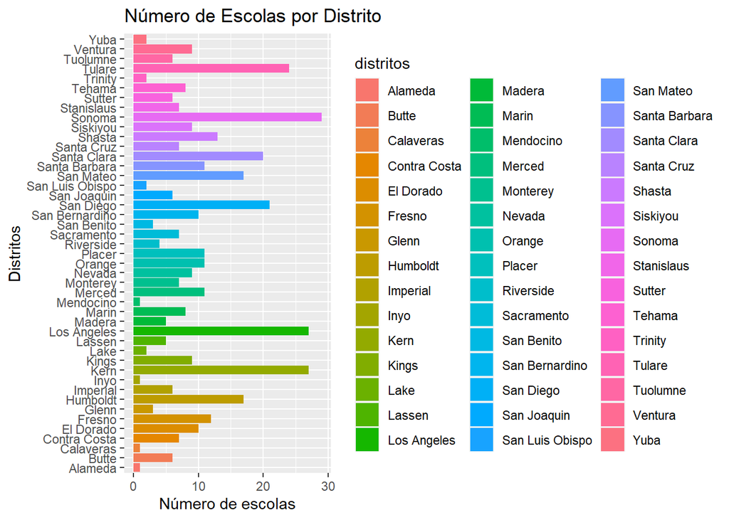

```r
freq.county <- table(CASchools$county)
freq.county.data <- data.frame(distritos = names(freq.county), freq.county = as.numeric(freq.county))
ggplot(freq.county.data, aes(x = freq.county, y = distritos, fill = distritos)) +
  geom_bar(stat = "identity") +
  labs(title = "Número de Escolas por Distrito", x = "Número de escolas", y = "Distritos")
```

- **Dicionário de dados**:
- *district*: Código do distrito;
- *school*: Nome da escola;
- *county*: Município;
- *grades*: Intervalo de notas do distrito;
- *students*: Total de inscrições(matrícula);
- *teachers*: Número de professores;
- *calworks*: Porcentagem de qualificação para CalWorks (assistência de renda);
- *lunch*: Porcentagem de qualificação para almoço a preço reduzido;
- *computer*:Número de computadores;
- *expenditure*: Despesa por aluno;
- *income*: Renda média do distrito (em US$ 1.000);
- *english*: Porcentagem de alunos de inglês;
- *read*: Pontuação média de leitura;
- *math*: Nota média de matemática.
4. Estudando a variável math:

Para avaliar visualmente a distribuição da coluna **math**(Nota média de matemática), utilizarei o gráfico Quantil-Quantil:

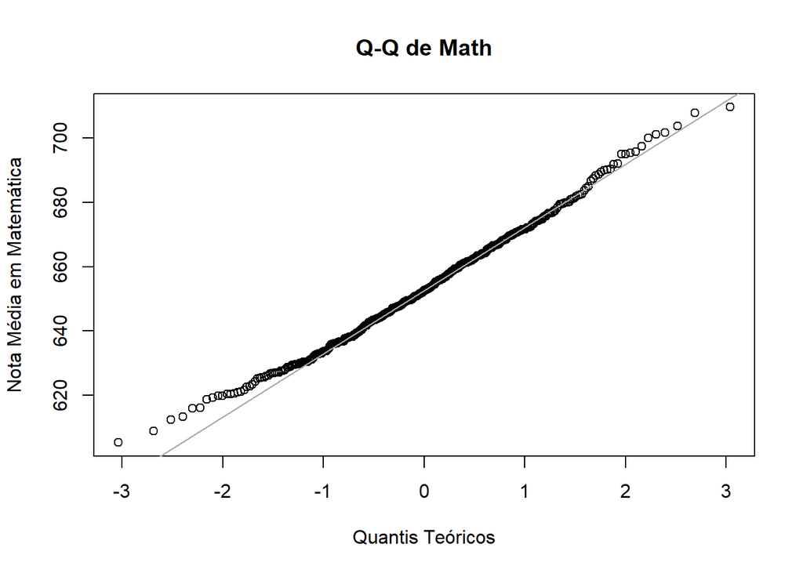

```r
attach(CASchools)
qqnorm(math, col = "grey1", ylab = "Nota Média em Matemática", xlab = "Quantis Teóricos",
       main = "Q-Q de Math")
qqline(math, col= "darkgrey")
```

Com a visualização, é notável a existência de dados extremos não tão distantes da linha. Avaliando melhor, irei analisar os resultados de skew.2SE e kurt.2SE. Se os valores estiverem entre -1 e 1, estarão dentro da normalidade.

```r
stat.desc(math, basic = FALSE, norm = TRUE)
```

```
##       median         mean      SE.mean CI.mean.0.95          var      std.dev
##  652.4499817  653.3426185    0.9151114    1.7987812  351.7200991   18.7542022
##     coef.var     skewness     skew.2SE     kurtosis     kurt.2SE   normtest.W
##    0.0287050    0.2541714    1.0670598   -0.1733195   -0.3646650    0.9936590
##   normtest.p
##    0.0759411
```

Como skew.2SE (1.0670598) está um pouco acima de 1, significa que há assimetria positiva. O valor de kurt.2SE (-0.3646650) está dentro da normalidade e indica uma distribuição mesocúrtica. Observando melhor a dispersão não tão significativa:

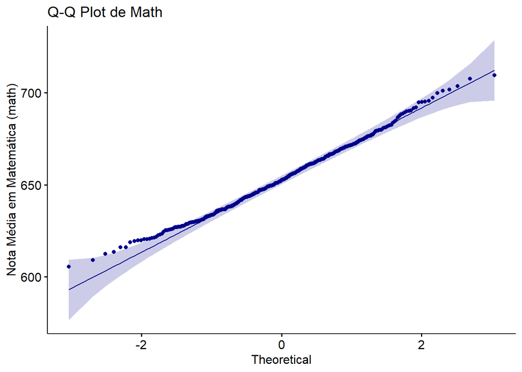

```r
ggqqplot(math, col = "blue4", ylab = "Nota Média em Matemática (math)",
         main = "Q-Q Plot de Math")
```

Analisando o teste de normalidade de Shapiro:

```r
shapiro.test(math)
```

```
##
##  Shapiro-Wilk normality test
##
## data:  math
## W = 0.99366, p-value = 0.07594
```

Como valor-p>0.05, consideramos que os dados podem ser de uma distribuição normal. Após conseguir visualizar os dados de *math* graficamente e analisar os dados dos testes, os resultados apontam para uma distribuição normal.

Então, irei observar *math*, e obter um novo conjunto de dados apenas com as variáveis numéricas de *CASchools*.

Retirando as variáveis que não serão analisadas nesse momento:

```r
Dados<- subset(CASchools, select=c(-county,-grades,-school,-...1,-district))
str(Dados)
```

```
## tibble [420 × 10] (S3: tbl_df/tbl/data.frame)
##  $ students   : num [1:420] 195 240 1550 243 1335 ...
##  $ teachers   : num [1:420] 10.9 11.1 82.9 14 71.5 ...
##  $ calworks   : num [1:420] 0.51 15.42 55.03 36.48 33.11 ...
##  $ lunch      : num [1:420] 2.04 47.92 76.32 77.05 78.43 ...
##  $ computer   : num [1:420] 67 101 169 85 171 25 28 66 35 0 ...
##  $ expenditure: num [1:420] 6385 5099 5502 7102 5236 ...
##  $ income     : num [1:420] 22.69 9.82 8.98 8.98 9.08 ...
##  $ english    : num [1:420] 0 4.58 30 0 13.86 ...
##  $ read       : num [1:420] 692 660 636 652 642 ...
##  $ math       : num [1:420] 690 662 651 644 640 ...
```

4. Estudando a correlação dos dados numéricos:

Analisando, inicialmente, a correlação das variáveis numéricas através da tabela de correlação:

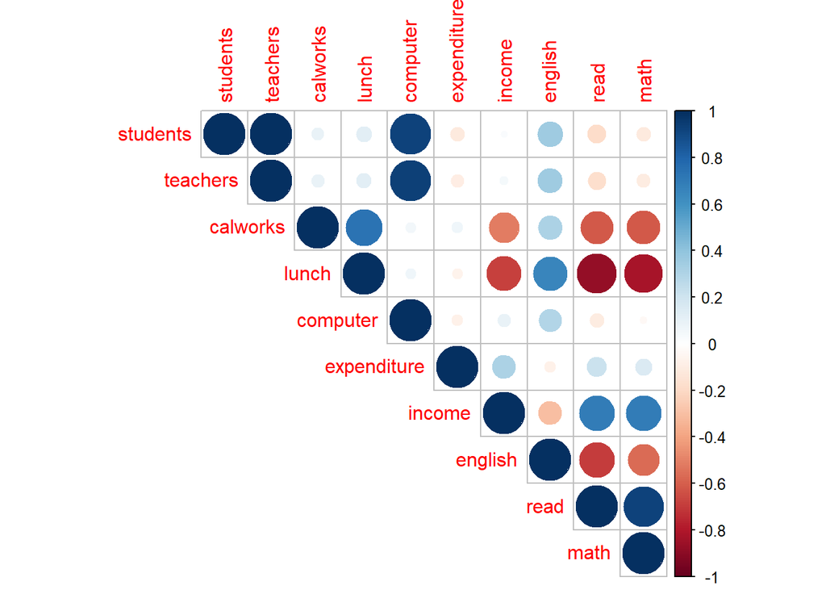

```r
corrplot(cor(Dados), type = "upper")
```

Se a correlação for positiva, as variáveis mudam na mesma direção, e se a correlação for negativa, as variáveis mudam em direções opostas.

Analisando as correlações para resultados positivos ou negativos (cor.= correlação):

1. cor.=1 -> correlação perfeita;
2. 0.2< cor. <0.4 -> correlação fraca;
3. 0.4< cor. <0.7 -> correlação moderada;
4. 0.7< cor. <0.9 -> correlação forte.

Irei observar a correlação de *math* com as variáveis que apresentaram correlação superior a 0.6, que são: **calworks**, **lunch**, **income** e **read**. Utilizando nível de significância de alfa = 0.05, se o valor-p < ou = alfa, a correlação é estatisticamente significativa.

Observando melhor os dados das correlações entre *math* e:

1. **calworks**- Porcentagem de qualificação para assistência de renda:

```r
cor.cal<- cor.test(math,calworks)
cor.cal
```

```
##
##  Pearson's product-moment correlation
##
## data:  math and calworks
## t = -16.058, df = 418, p-value < 2.2e-16
## alternative hypothesis: true correlation is not equal to 0
## 95 percent confidence interval:
##  -0.6735662 -0.5547955
## sample estimates:
##        cor
## -0.6176908
```

2. **lunch**- Porcentagem de qualificação para almoço a preço reduzido:

```r
cor.lun<- cor.test(math,lunch)
cor.lun
```

```
##
##  Pearson's product-moment correlation
##
## data:  math and lunch
## t = -29.623, df = 418, p-value < 2.2e-16
## alternative hypothesis: true correlation is not equal to 0
## 95 percent confidence interval:
##  -0.8516336 -0.7895025
## sample estimates:
##        cor
## -0.8230145
```

3. **income**- Renda média do distrito (em US$ 1.000):

```r
cor.inc<- cor.test(math,income)
cor.inc
```

```
##
##  Pearson's product-moment correlation
##
## data:  math and income
## t = 20.006, df = 418, p-value < 2.2e-16
## alternative hypothesis: true correlation is not equal to 0
## 95 percent confidence interval:
##  0.6470117 0.7452127
## sample estimates:
##       cor
## 0.6993981
```

4. **read**- Pontuação média de leitura:

```r
cor.read<- cor.test(math,read)
cor.read
```

```
##
##  Pearson's product-moment correlation
##
## data:  math and read
## t = 49.005, df = 418, p-value < 2.2e-16
## alternative hypothesis: true correlation is not equal to 0
## 95 percent confidence interval:
##  0.9073417 0.9359362
## sample estimates:
##       cor
## 0.9229015
```

De acordo com os testes, e seguindo a base de correlação informada acima, todas as variáveis analisadas estão correlacionadas moderadamente ou fortemente com *math*.

5. Fazendo análise gráfica entre *math* e as variáveis correlacionadas:
- **Read**:

Das variáveis analisadas, *read* apresenta maior taxa de correlação positiva. Visualizando graficamente:

Gráfico de *math* e *read*:

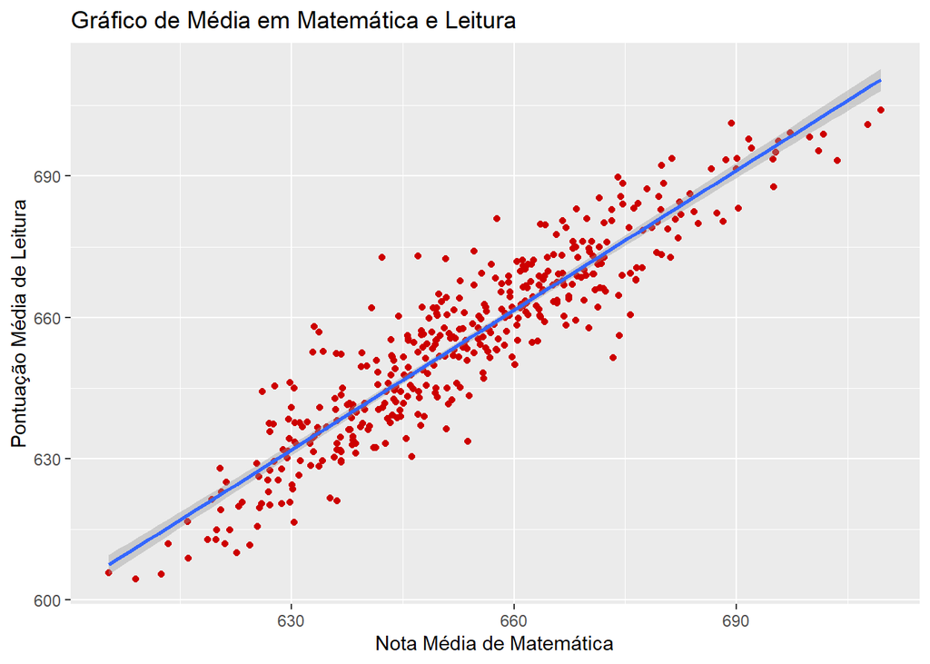

```r
CASchools%>%
  ggplot(mapping = aes(x=math, y=read)) + geom_point(color="red3") + xlab("Nota Média de Matemática") +
  ylab("Pontuação Média de Leitura") + ggtitle("Gráfico de Média em Matemática e Leitura") +
  geom_smooth(method = lm)
```

Apesar de apresentar pontos extremos, é possível visualizar o crescimento em conjunto e no mesmo sentido dos dados de *math* e *read*, e também afirmar que as variáveis estão correlacionadas significativamente *(cor=0.92)*. Confirmando as informações do intervalo de confiança estreito, visto no teste de correlação realizado anteriormente, com percentual de confiança de 95%: *[0.9073417, 0.9359362]*.

- **Lunch**:

A segunda correlação mais significativa é entre *math* e *lunch*, e é negativa. Representando essa correlação graficamente:

Gráfico de *math* e *lunch*:

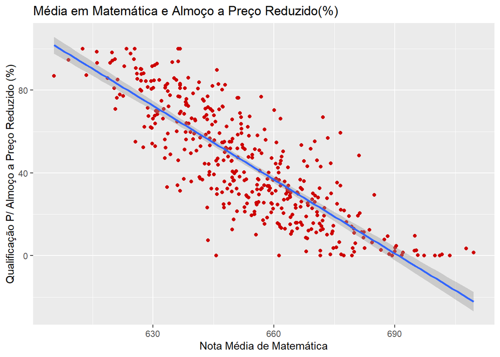

```r
CASchools%>%
  ggplot(mapping = aes(x=math, y=lunch)) + geom_point(color="red3") + xlab("Nota Média de Matemática") +
  ylab("Qualificação P/ Almoço a Preço Reduzido (%)") +
  ggtitle("Média em Matemática e Almoço a Preço Reduzido(%)") +
  geom_smooth(method = lm)
```

Verificamos que existem dados extremos em relação a linha, mas é notória a correlação negativa entre *math* e *lunch*. Sendo assim, podemos afirmar que quanto menor for a porcentagem de qualificação para almoço a preço reduzido, maior a nota média em matemática. Com correlação igual a *-0.8230145*, e intervalo de confiança entre *[-0.8516336, -0.7895025]*.

- **Income**:

A correlação apresentada entre *math* e *income* está classificada como moderada, crescendo na mesma direção, de acordo com os dados apresentados anteriormente *(cor.= 0.6993981)*.

Gráfico de *math* e *income*, com visualização de cores por distrito:

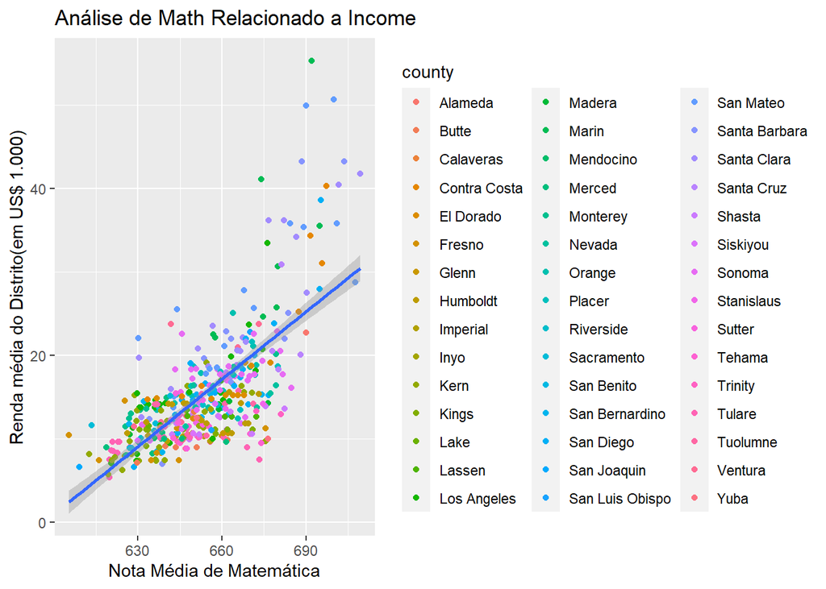

```r
CASchools%>%
  ggplot(mapping = aes(x=math, y=income)) + geom_point(aes(color=county)) +
  xlab("Nota Média de Matemática") + ylab("Renda média do Distrito(em US$ 1.000)") +
  geom_smooth(method = "lm") + ggtitle("Análise de Math Relacionado a Income")
```

Entretanto, irei observar a média geral de *math*, e a correlação entre *math* e *income* para os dados com nota superior à media geral. i) Obtendo a média de *math*:

```r
media.math<- round(mean(math))
media.math
```

```
## [1] 653
```

2. Selecionando data frame com as escolas em que a média em matemática é superior à média geral, e visualizando o gráfico:

```r
attach(CASchools)
acima.math<- subset(math, math > media.math)
abaixo.math<- subset(math, math <= media.math)

prop.acima <- length(acima.math) / length(CASchools$math)
prop.abaixo <- length(abaixo.math) / length(CASchools$math)
prop.math<- c(prop.acima, prop.abaixo)
prop.math
```

```
## [1] 0.4880952 0.5119048
```

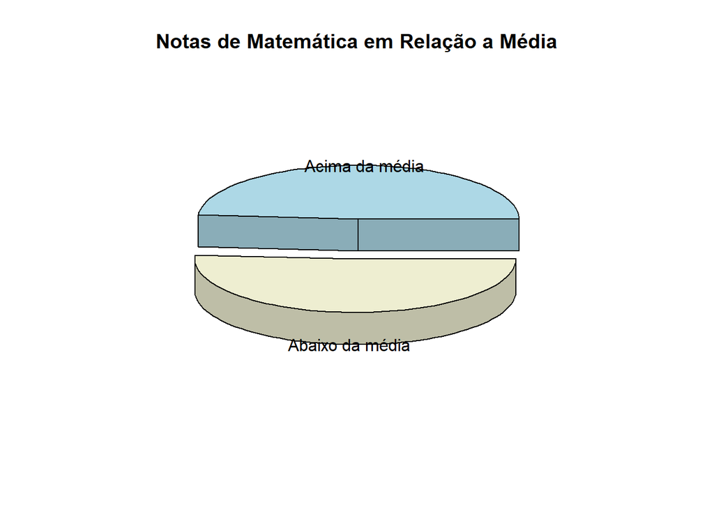

```r
rótulos <- c("Acima da média", "Abaixo da média")
cores<- colorRampPalette(c("lightblue", "lightyellow2"))
library(plotrix)

pie3D(prop.math,labels=rótulos,
      col= cores(2), # cor
      explode=0.25, # fatias
      labelcex=1, #fonte do rótulo
      main= "Notas de Matemática em Relação a Média")
```

3. Visualizando o gráfico para *math* e *income*, com *math* superior à média geral:

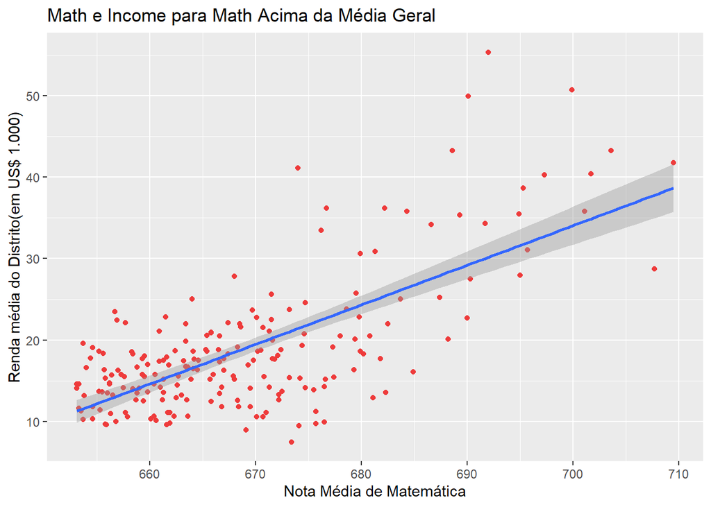

```r
acima.math.data<- (data.frame(subset(CASchools, math>media.math)))
acima.math.data%>%
ggplot(mapping = aes(x=math, y=income)) + geom_point(color="brown2") +
  xlab("Nota Média de Matemática") + ylab("Renda média do Distrito(em US$ 1.000)") +
  geom_smooth(method = "lm") + ggtitle("Math e Income para Math Acima da Média Geral")
```

- **Calworks**:

A correlação apresentada entre *math* e *calworks* está classificada como moderada, aumentando em direções opostas, de acordo com os dados apresentados anteriormente *(cor.= -0.6176908)*.

Gráfico da relação entre *math* e *calworks* por distrito:

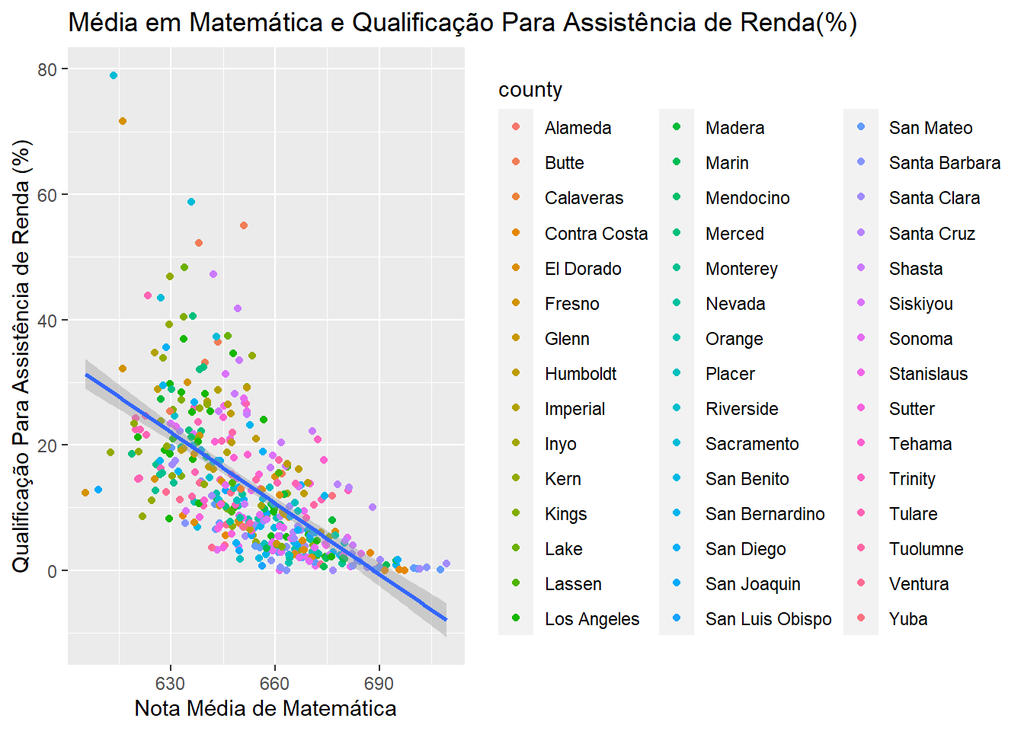

```r
CASchools%>%
ggplot(mapping = aes(x=math, y=calworks)) + geom_point(aes(color=county)) +
  xlab("Nota Média de Matemática") + ylab("Qualificação Para Assistência de Renda (%)") +
  ggtitle("Média em Matemática e Qualificação Para Assistência de Renda(%)") +
  geom_smooth(method = lm)
```

Assim como na correlação entre *math* e *income*, em *math* e *calworks* também existem pontos extremos e não segue uma distribuição normal. Porém, neste gráfico, também é possível notar um comportamento similar nas notas mais altas.

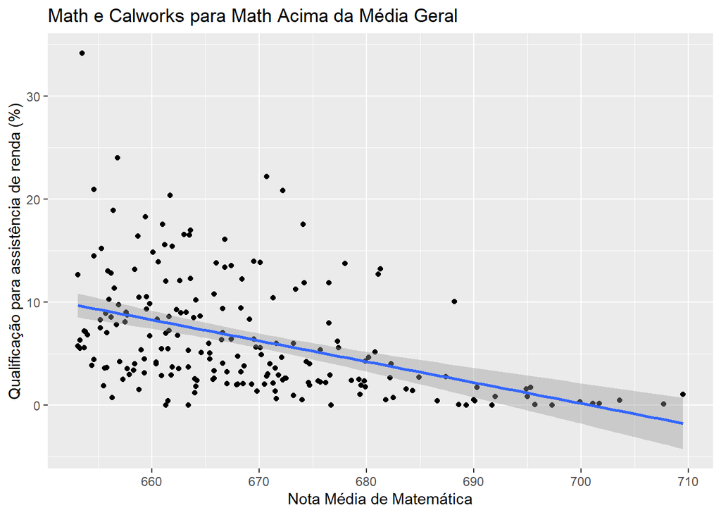

```r
acima.math.data%>%
  ggplot(mapping = aes(x=math, y=calworks)) + geom_point() +
  xlab("Nota Média de Matemática") + ylab("Qualificação para assistência de renda (%)") +
  geom_smooth(method = "lm") + ggtitle("Math e Calworks para Math Acima da Média Geral")
```